# Project 3: Part I - Ford GoBike Trip Data Exploration

## Introduction

> The dataset, 201902-fordgobike-tripdata.csv, is downloaded from Ford GoBike and licensed by Ford GoBike. This dataset includes 183,412 bike trips with 16 features such as locations, time, and user attributes. There are start and end stations. Thus, the following analysis is performed by this subsetted dataset.

## Preliminary Wrangling

> This document explores a dataset including time, stations, and users' attributes for 183412 bike trips

```python
# import all packages and set plots to be embedded inline
import numpy as np
import pandas as pd
import matplotlib.pyplot as plt
import seaborn as sb
import calendar
import math
import time

%matplotlib inline

# suppress warnings from final output
import warnings
warnings.simplefilter("ignore")
```

```python
# Import Ford GoBike csv file into jupyter notebook
df_fgb = pd.read_csv('201902-fordgobike-tripdata.csv')
```

```python
# Find out the structure of the dataset
print(df_fgb.shape)
print(df_fgb.info())
print(df_fgb.head())
```

```
(183412, 16)
<class 'pandas.core.frame.DataFrame'>
RangeIndex: 183412 entries, 0 to 183411
Data columns (total 16 columns):
 #   Column                   Non-Null Count   Dtype
---  ------                   --------------   -----
 0   duration_sec             183412 non-null  int64
 1   start_time               183412 non-null  object
 2   end_time                 183412 non-null  object
 3   start_station_id         183215 non-null  float64
 4   start_station_name       183215 non-null  object
 5   start_station_latitude   183412 non-null  float64
 6   start_station_longitude  183412 non-null  float64
 7   end_station_id           183215 non-null  float64
 8   end_station_name         183215 non-null  object
 9   end_station_latitude     183412 non-null  float64
 10  end_station_longitude    183412 non-null  float64
 11  bike_id                  183412 non-null  int64
 12  user_type                183412 non-null  object
 13  member_birth_year        175147 non-null  float64
 14  member_gender            175147 non-null  object
 15  bike_share_for_all_trip  183412 non-null  object
dtypes: float64(7), int64(2), object(7)
memory usage: 22.4+ MB
None
   duration_sec                start_time                  end_time  \
0         52185  2019-02-28 17:32:10.1450  2019-03-01 08:01:55.9750
1         42521  2019-02-28 18:53:21.7890  2019-03-01 06:42:03.0560
2         61854  2019-02-28 12:13:13.2180  2019-03-01 05:24:08.1460
3         36490  2019-02-28 17:54:26.0100  2019-03-01 04:02:36.8420
4          1585  2019-02-28 23:54:18.5490  2019-03-01 00:20:44.0740

   start_station_id                                start_station_name  \
0              21.0  Montgomery St BART Station (Market St at 2nd St)
1              23.0                     The Embarcadero at Steuart St
2              86.0                           Market St at Dolores St
3             375.0                           Grove St at Masonic Ave
4               7.0                               Frank H Ogawa Plaza

   start_station_latitude  start_station_longitude  end_station_id  \
```

[output cut: 11 more lines]

```
4                         10th Ave at E 15th St             37.792714

   end_station_longitude  bike_id   user_type  member_birth_year  \
0            -122.402923     4902    Customer             1984.0
1            -122.393170     2535    Customer                NaN
2            -122.404904     5905    Customer             1972.0
3            -122.444293     6638  Subscriber             1989.0
4            -122.248780     4898  Subscriber             1974.0

  member_gender bike_share_for_all_trip
0          Male                      No
1           NaN                      No
2          Male                      No
3         Other                      No
4          Male                     Yes
```

### What is the structure of your dataset?

> This dataset includes 183412 trips with 16 features.

| Variable Name | Definition |
| --- | --- |
| duration_sec | int64 |
| start_time | object |
| end_time | object |
| start_station_id | float64 |
| start_station_name | object |
| start_station_latitude | float64 |
| start_station_longitude | float64 |
| end_station_id | float64 |
| end_station_name | object |
| end_station_latitude | float64 |
| end_station_longitude | float64 |
| bike_id | int64 |
| user_type | object |
| member_birth_year | float64 |
| member_gender | object |
| bike_share_for_all_trip | object |

### What is/are the main feature(s) of interest in your dataset?

I am most interested in figuring out when are most trips taken because this dataset includes start time/location and end time/location. I will focus on the starting points.

- I am also interested in the following characteristics (age, sex, and user_type) of the riders and the duration of the trips in these time points and locations.

### What features in the dataset do you think will help support your investigation into your feature(s) of interest?

I expect the Caltrain or Bart stations in San Francisco will have more trips than other locations because those stations are in the center of the city and connect to other major transportations. Morning and afternoon will have more trips than night time due to rush hours. Also, I assume younger riders are more than older riders because of physical abilities. Moreover, based on the pricing, subscribers are more likely to ride frequently than customers. And it's hard to expect female riders are more than the males, so I leave this topic in the analysis.

```python
# 1. Convert time variables from string to datetime
# a. month of the year
df_fgb['start_time'] = pd.to_datetime(df_fgb['start_time'])
df_fgb['start_month_num'] = df_fgb['start_time'].apply(lambda time: time.month)
df_fgb['start_month_char'] = df_fgb['start_month_num'].apply(lambda x: calendar.month_abbr[x])
```

```python
# Test: take a loo at start_month_num and start_month_char
print(df_fgb['start_month_num'].value_counts())
print(df_fgb['start_month_char'].value_counts())
```

```
2    183412
Name: start_month_num, dtype: int64
Feb    183412
Name: start_month_char, dtype: int64
```

```python
 # b. morning, afternoon, night of a day
df_fgb['start_hour'] = df_fgb['start_time'].apply(lambda time: time.hour)
df_fgb['period_day'] = 'morning'
df_fgb['period_day'][(df_fgb['start_hour'] >= 12) & (df_fgb['start_hour'] <= 17)] = 'afternoon'
df_fgb['period_day'][(df_fgb['start_hour'] >= 18) & (df_fgb['start_hour'] <= 23)] = 'night'
```

```python
# Test: start hour and time of day
print(df_fgb['start_hour'].value_counts())
print(df_fgb['period_day'].value_counts())
```

```
17    21864
8     21056
18    16827
9     15903
16    14169
7     10614
19     9881
15     9174
12     8724
13     8551
10     8364
14     8152
11     7884
20     6482
21     4561
6      3485
22     2916
23     1646
0       925
5       896
1       548
2       381
4       235
3       174
Name: start_hour, dtype: int64
afternoon    70634
morning      70465
night        42313
Name: period_day, dtype: int64
```

```python
# c. Day of the week
df_fgb['start_weekday_num'] = df_fgb['start_time'].apply(lambda time: time.dayofweek)
dmap = {0:'Mon',1:'Tue',2:'Wed',3:'Thu',4:'Fri',5:'Sat',6:'Sun'}
df_fgb['start_weekday_char'] = df_fgb['start_weekday_num'].map(dmap)
```

```python
# Test: take a look at start_weekday_num and start_weekday_char
print(df_fgb['start_weekday_num'].value_counts())
print(df_fgb['start_weekday_char'].value_counts())
```

```
3    35197
1    31813
2    29641
4    28981
0    26852
6    15523
5    15405
Name: start_weekday_num, dtype: int64
Thu    35197
Tue    31813
Wed    29641
Fri    28981
Mon    26852
Sun    15523
Sat    15405
Name: start_weekday_char, dtype: int64
```

```python
# convert time period, month, and weekday into ordered categorical types
ordinal_var_dict = {'start_month_char': ['Feb'],
                    'period_day': ['morning', 'afternoon', 'night'],
                    'start_weekday_char': ['Mon', 'Tue', 'Wed', 'Thu', 'Fri', 'Sat', 'Sun']}

for var in ordinal_var_dict:
    ordered_var = pd.api.types.CategoricalDtype(ordered = True,
                                                categories = ordinal_var_dict[var])
    df_fgb[var] = df_fgb[var].astype(ordered_var)
```

```python
# 2. Create ages
df_fgb['age'] = df_fgb['member_birth_year'].apply(lambda x: 2019 - x)
```

```python
# Test: age
df_fgb['age'].describe()
```

```
count    175147.000000
mean         34.193563
std          10.116689
min          18.000000
25%          27.000000
50%          32.000000
75%          39.000000
max         141.000000
Name: age, dtype: float64
```

## Univariate Exploration

I begin by looking into the start time and start location of this dataset.

```python
# 1. Location: there are 329 start stations.
print(len(df_fgb['start_station_name'].value_counts()))
df_fgb['start_station_name'].value_counts()
```

```
329
```

```
Market St at 10th St                                         3904
San Francisco Caltrain Station 2  (Townsend St at 4th St)    3544
Berry St at 4th St                                           3052
Montgomery St BART Station (Market St at 2nd St)             2895
Powell St BART Station (Market St at 4th St)                 2760
                                                             ...
Willow St at Vine St                                            9
Parker Ave at McAllister St                                     7
Palm St at Willow St                                            4
21st Ave at International Blvd                                  4
16th St Depot                                                   2
Name: start_station_name, Length: 329, dtype: int64
```

```python
# Do they have as high traffic as end stations? Looks like the answer is yes!
print(len(df_fgb['end_station_name'].value_counts()))
df_fgb['end_station_name'].value_counts()
```

```
329
```

```
San Francisco Caltrain Station 2  (Townsend St at 4th St)    4857
Market St at 10th St                                         3973
Montgomery St BART Station (Market St at 2nd St)             3647
San Francisco Ferry Building (Harry Bridges Plaza)           3368
Powell St BART Station (Market St at 4th St)                 2997
                                                             ...
Parker Ave at McAllister St                                     9
Palm St at Willow St                                            7
16th St Depot                                                   6
21st Ave at International Blvd                                  6
Willow St at Vine St                                            5
Name: end_station_name, Length: 329, dtype: int64
```

```python
# 2. Location: there are 329 start stations.
print(len(df_fgb['start_station_name'].value_counts()))
df_fgb['start_station_name'].value_counts(10)
```

```
329
```

```
Market St at 10th St                                         0.021308
San Francisco Caltrain Station 2  (Townsend St at 4th St)    0.019343
Berry St at 4th St                                           0.016658
Montgomery St BART Station (Market St at 2nd St)             0.015801
Powell St BART Station (Market St at 4th St)                 0.015064
                                                               ...
Willow St at Vine St                                         0.000049
Parker Ave at McAllister St                                  0.000038
Palm St at Willow St                                         0.000022
21st Ave at International Blvd                               0.000022
16th St Depot                                                0.000011
Name: start_station_name, Length: 329, dtype: float64
```

```python
# Subset the dataset by keeping only top 10 locations with high traffic, df_top10.
locs = ['Market St at 10th St','San Francisco Caltrain Station 2  (Townsend St at 4th St)', 'Berry St at 4th St',
         'Montgomery St BART Station (Market St at 2nd St)', 'Powell St BART Station (Market St at 4th St)','San Francisco Ferry Building (Harry Bridges Plaza)', 'San Francisco Caltrain (Townsend St at 4th St)',
        'Powell St BART Station (Market St at 5th St)', 'Howard St at Beale St', 'Steuart St at Market St']
df_top10 = df_fgb.loc[df_fgb['start_station_name'].isin(locs)]
```

```python
# Test and see if only keep top 10 station
print(df_top10['start_station_name'].value_counts().head(10))
print(df_top10['end_station_name'].value_counts().head(10))
```

```
Market St at 10th St                                         3904
San Francisco Caltrain Station 2  (Townsend St at 4th St)    3544
Berry St at 4th St                                           3052
Montgomery St BART Station (Market St at 2nd St)             2895
Powell St BART Station (Market St at 4th St)                 2760
San Francisco Ferry Building (Harry Bridges Plaza)           2710
San Francisco Caltrain (Townsend St at 4th St)               2703
Powell St BART Station (Market St at 5th St)                 2327
Howard St at Beale St                                        2293
Steuart St at Market St                                      2283
Name: start_station_name, dtype: int64
The Embarcadero at Sansome St                                989
Market St at 10th St                                         928
San Francisco Ferry Building (Harry Bridges Plaza)           912
Montgomery St BART Station (Market St at 2nd St)             856
San Francisco Caltrain (Townsend St at 4th St)               821
San Francisco Caltrain Station 2  (Townsend St at 4th St)    807
Berry St at 4th St                                           780
2nd St at Townsend St                                        722
Powell St BART Station (Market St at 4th St)                 671
Powell St BART Station (Market St at 5th St)                 539
Name: end_station_name, dtype: int64
```

```python
# After subsetting top 10 stations with the most trips, create a countplot to see the distribution and order from top 1 to top 10
st_stat_counts = df_top10['start_station_name'].value_counts()
st_stat_order = st_stat_counts.index
```

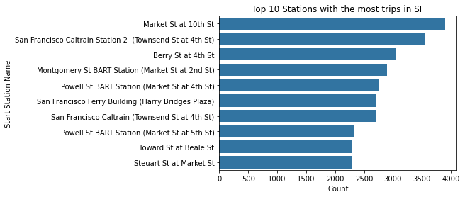

```python
base_color = sb.color_palette()[0]
sb.countplot(data=df_top10, y='start_station_name', color=base_color, order=st_stat_order)
plt.xlabel('Count')
plt.ylabel('Start Station Name')
plt.title('Top 10 Stations with the most trips in SF');
```

After checking start and end stations, most stations in San Francisco connect to public transportations such as Caltrain, Bart and Ferry. The Embarcadero at Sansome St is very close to Ferry building and located in financial district. Market St at 10th St and Berry St at 4th St are also closed to Bart station. I will look into the time factors in these 10 locations.

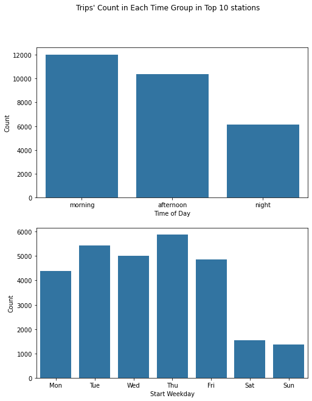

```python
# 1.1: Time
fig, ax = plt.subplots(nrows=2, figsize = [8,10])
default_color = sb.color_palette()[0]
sb.countplot(data = df_top10, x = 'period_day', color = default_color, ax = ax[0])
sb.countplot(data = df_top10, x = 'start_weekday_char', color = default_color, ax = ax[1])
ax[0].set_xlabel('Time of Day')
ax[0].set_ylabel('Count')
ax[1].set_xlabel('Start Weekday')
ax[1].set_ylabel('Count')
fig.suptitle('Trips\' Count in Each Time Group in Top 10 stations');
```

Based on the above figures, the following were the findings in the top 10 start station:

1. During the day, there are more trips in the morning and afternoon than the night. It probably because of rush hours. Also, the number of trips in the afternoon is less than the morning. I assumed when riders come back home, they might not be able to go back in the afternoon. Probably, they come back during the night so some trips fall into nighttime.
2. It makes sense that there are more trips during the weekdays and less trips during the weekends because of working schedule.

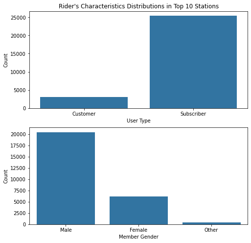

```python
# 3. Rider's characteristics: the distributions of user type and gender
fig, ax = plt.subplots(nrows=2, figsize = [8,8])
default_color = sb.color_palette()[0]
sb.countplot(data = df_top10, x = 'user_type', color = default_color, ax = ax[0])
sb.countplot(data = df_top10, x = 'member_gender', color = default_color, ax = ax[1])
ax[0].set_xlabel('User Type')
ax[0].set_ylabel('Count')
ax[1].set_xlabel('Member Gender')
ax[1].set_ylabel('Count')
ax[0].set_title('Rider\'s Characteristics Distributions in Top 10 Stations');
```

```python
# Take a look at the 'Other' group in gender.
df_top10.query('member_gender == "Other"')
```

|  | duration_sec | start_time | end_time | start_station_id | start_station_name | start_station_latitude | start_station_longitude | end_station_id | end_station_name | end_station_latitude | ... | member_birth_year | member_gender | bike_share_for_all_trip | start_month_num | start_month_char | start_hour | period_day | start_weekday_num | start_weekday_char | age |
| --- | --- | --- | --- | --- | --- | --- | --- | --- | --- | --- | --- | --- | --- | --- | --- | --- | --- | --- | --- | --- | --- |
| 190 | 515 | 2019-02-28 22:28:11.347 | 2019-02-28 22:36:46.3890 | 58.0 | Market St at 10th St | 37.776619 | -122.417385 | 321.0 | 5th St at Folsom | 37.780146 | ... | 1981.0 | Other | No | 2 | NaN | 22 | night | 3 | Thu | 38.0 |
| 1106 | 851 | 2019-02-28 19:36:45.231 | 2019-02-28 19:50:57.0650 | 67.0 | San Francisco Caltrain Station 2 (Townsend St... | 37.776639 | -122.395526 | 74.0 | Laguna St at Hayes St | 37.776435 | ... | 1985.0 | Other | No | 2 | NaN | 19 | night | 3 | Thu | 34.0 |
| 1176 | 1484 | 2019-02-28 19:17:32.459 | 2019-02-28 19:42:17.3290 | 21.0 | Montgomery St BART Station (Market St at 2nd St) | 37.789625 | -122.400811 | 134.0 | Valencia St at 24th St | 37.752428 | ... | 1986.0 | Other | No | 2 | NaN | 19 | night | 3 | Thu | 33.0 |
| 1432 | 398 | 2019-02-28 19:09:44.294 | 2019-02-28 19:16:23.2800 | 3.0 | Powell St BART Station (Market St at 4th St) | 37.786375 | -122.404904 | 67.0 | San Francisco Caltrain Station 2 (Townsend St... | 37.776639 | ... | 1985.0 | Other | No | 2 | NaN | 19 | night | 3 | Thu | 34.0 |
| 1800 | 1441 | 2019-02-28 18:25:12.218 | 2019-02-28 18:49:13.8080 | 21.0 | Montgomery St BART Station (Market St at 2nd St) | 37.789625 | -122.400811 | 115.0 | Jackson Playground | 37.765026 | ... | 1968.0 | Other | No | 2 | NaN | 18 | night | 3 | Thu | 51.0 |
| ... | ... | ... | ... | ... | ... | ... | ... | ... | ... | ... | ... | ... | ... | ... | ... | ... | ... | ... | ... | ... | ... |
| 179849 | 324 | 2019-02-01 12:44:28.223 | 2019-02-01 12:49:52.7190 | 3.0 | Powell St BART Station (Market St at 4th St) | 37.786375 | -122.404904 | 321.0 | 5th St at Folsom | 37.780146 | ... | 1981.0 | Other | No | 2 | NaN | 12 | afternoon | 4 | Fri | 38.0 |
| 180075 | 499 | 2019-02-01 12:05:01.631 | 2019-02-01 12:13:20.6360 | 3.0 | Powell St BART Station (Market St at 4th St) | 37.786375 | -122.404904 | 58.0 | Market St at 10th St | 37.776619 | ... | 1989.0 | Other | No | 2 | NaN | 12 | afternoon | 4 | Fri | 30.0 |
| 180249 | 1260 | 2019-02-01 11:24:29.535 | 2019-02-01 11:45:30.3980 | 3.0 | Powell St BART Station (Market St at 4th St) | 37.786375 | -122.404904 | 27.0 | Beale St at Harrison St | 37.788059 | ... | 1974.0 | Other | Yes | 2 | NaN | 11 | morning | 4 | Fri | 45.0 |
| 180759 | 451 | 2019-02-01 10:09:02.836 | 2019-02-01 10:16:34.3520 | 21.0 | Montgomery St BART Station (Market St at 2nd St) | 37.789625 | -122.400811 | 58.0 | Market St at 10th St | 37.776619 | ... | 1987.0 | Other | No | 2 | NaN | 10 | morning | 4 | Fri | 32.0 |
| 180778 | 294 | 2019-02-01 10:08:45.510 | 2019-02-01 10:13:39.9710 | 5.0 | Powell St BART Station (Market St at 5th St) | 37.783899 | -122.408445 | 64.0 | 5th St at Brannan St | 37.776754 | ... | 1983.0 | Other | No | 2 | NaN | 10 | morning | 4 | Fri | 36.0 |

449 rows × 23 columns

In these top 10 trips stations, base on the above figures, I have the following findings:

- It makes sense that there are more subscribers than customers. Based on the [pricing page](https://www.fordgobike.com/pricing), monthly membership only takes 15 dollars. For regular customers, one trip takes 2 dollars and one day takes 10 dollars. If riders are commuters or long-term users, it does not make sense for them to choose one time or two time purchases instead of being the members.
- For the gender groups, the number of trips in male riders is 3 times more than the number of trips in females. Why is that? I will investigate this more in the following.
- There are few riders with 'Other' gender. It's not clear that the riders are not willing to reveal or there are data entry issues.

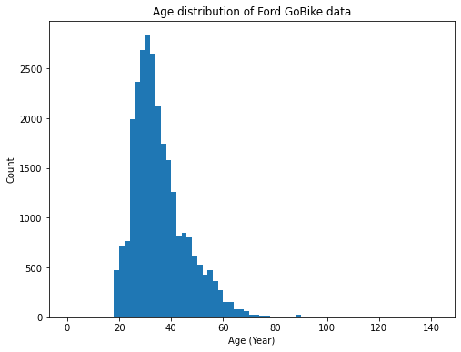

```python
# 4. Age: based on the distribution, we can tell it's right skewed and has some outliers between 100 and 120.
plt.figure(figsize=(8,6))
bins = np.arange(0, df_fgb['age'].max()+2, 2)
plt.hist(data=df_top10, x='age', bins=bins)
plt.xlabel('Age (Year)')
plt.ylabel('Count')
plt.title('Age distribution of Ford GoBike data');
```

```python
df_top10['age'].describe()
```

```
count    27009.000000
mean        35.014736
std         10.238980
min         18.000000
25%         28.000000
50%         33.000000
75%         40.000000
max        141.000000
Name: age, dtype: float64
```

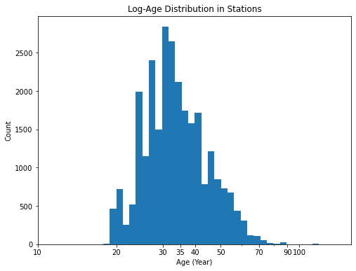

```python
# there's a long tail in the distribution, so let's put it on a log scale instead
log_binsize = 0.025
bins = 10 ** np.arange(1.2, np.log10(df_top10['age'].max())+log_binsize, log_binsize)

plt.figure(figsize=[8, 6])
plt.hist(data = df_top10, x = 'age', bins = bins)
plt.xscale('log')
plt.xticks([10,20,30,35,40,50,70,90,100], [10,20,30,35,40,50,70,90,100])
plt.xlabel('Age (Year)')
plt.ylabel('Count')
plt.title('Log-Age Distribution in Stations');
```

From the figure, most of riders are around 30 years old. Even though there are some riders ages older than 90 years old looks like high outliers, before checking their physical abilities data, I will keep them in the dataset.

```python
# There are some bikers with age older than 100 years old. Let's take a look at them.
df_fgb.query('age > 100')
```

|  | duration_sec | start_time | end_time | start_station_id | start_station_name | start_station_latitude | start_station_longitude | end_station_id | end_station_name | end_station_latitude | ... | member_birth_year | member_gender | bike_share_for_all_trip | start_month_num | start_month_char | start_hour | period_day | start_weekday_num | start_weekday_char | age |
| --- | --- | --- | --- | --- | --- | --- | --- | --- | --- | --- | --- | --- | --- | --- | --- | --- | --- | --- | --- | --- | --- |
| 1285 | 148 | 2019-02-28 19:29:17.627 | 2019-02-28 19:31:45.9670 | 158.0 | Shattuck Ave at Telegraph Ave | 37.833279 | -122.263490 | 173.0 | Shattuck Ave at 55th St | 37.840364 | ... | 1900.0 | Male | Yes | 2 | NaN | 19 | night | 3 | Thu | 119.0 |
| 10827 | 1315 | 2019-02-27 19:21:34.436 | 2019-02-27 19:43:30.0080 | 343.0 | Bryant St at 2nd St | 37.783172 | -122.393572 | 375.0 | Grove St at Masonic Ave | 37.774836 | ... | 1900.0 | Male | No | 2 | NaN | 19 | night | 2 | Wed | 119.0 |
| 16087 | 1131 | 2019-02-27 08:37:36.864 | 2019-02-27 08:56:28.0220 | 375.0 | Grove St at Masonic Ave | 37.774836 | -122.446546 | 36.0 | Folsom St at 3rd St | 37.783830 | ... | 1900.0 | Male | No | 2 | NaN | 8 | morning | 2 | Wed | 119.0 |
| 19375 | 641 | 2019-02-26 17:03:19.855 | 2019-02-26 17:14:01.6190 | 9.0 | Broadway at Battery St | 37.798572 | -122.400869 | 30.0 | San Francisco Caltrain (Townsend St at 4th St) | 37.776598 | ... | 1900.0 | Male | No | 2 | NaN | 17 | afternoon | 1 | Tue | 119.0 |
| 21424 | 1424 | 2019-02-26 08:58:02.904 | 2019-02-26 09:21:47.7490 | 375.0 | Grove St at Masonic Ave | 37.774836 | -122.446546 | 343.0 | Bryant St at 2nd St | 37.783172 | ... | 1900.0 | Male | No | 2 | NaN | 8 | morning | 1 | Tue | 119.0 |
| ... | ... | ... | ... | ... | ... | ... | ... | ... | ... | ... | ... | ... | ... | ... | ... | ... | ... | ... | ... | ... | ... |
| 171996 | 1368 | 2019-02-03 17:33:54.607 | 2019-02-03 17:56:42.9490 | 37.0 | 2nd St at Folsom St | 37.785000 | -122.395936 | 375.0 | Grove St at Masonic Ave | 37.774836 | ... | 1900.0 | Male | No | 2 | NaN | 17 | afternoon | 6 | Sun | 119.0 |
| 173711 | 993 | 2019-02-03 09:45:30.464 | 2019-02-03 10:02:04.1690 | 375.0 | Grove St at Masonic Ave | 37.774836 | -122.446546 | 36.0 | Folsom St at 3rd St | 37.783830 | ... | 1900.0 | Male | No | 2 | NaN | 9 | morning | 6 | Sun | 119.0 |
| 177708 | 1527 | 2019-02-01 19:09:28.387 | 2019-02-01 19:34:55.9630 | 343.0 | Bryant St at 2nd St | 37.783172 | -122.393572 | 375.0 | Grove St at Masonic Ave | 37.774836 | ... | 1900.0 | Male | No | 2 | NaN | 19 | night | 4 | Fri | 119.0 |
| 177885 | 517 | 2019-02-01 18:38:40.471 | 2019-02-01 18:47:18.3920 | 25.0 | Howard St at 2nd St | 37.787522 | -122.397405 | 30.0 | San Francisco Caltrain (Townsend St at 4th St) | 37.776598 | ... | 1902.0 | Female | No | 2 | NaN | 18 | night | 4 | Fri | 117.0 |
| 182830 | 428 | 2019-02-01 07:45:05.934 | 2019-02-01 07:52:14.9220 | 284.0 | Yerba Buena Center for the Arts (Howard St at ... | 37.784872 | -122.400876 | 67.0 | San Francisco Caltrain Station 2 (Townsend St... | 37.776639 | ... | 1901.0 | Male | No | 2 | NaN | 7 | morning | 4 | Fri | 118.0 |

72 rows × 23 columns

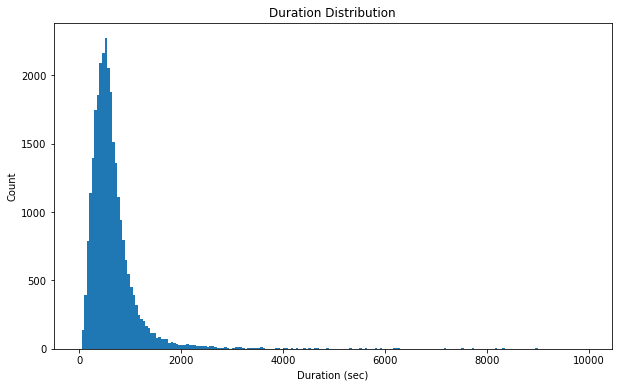

```python
# 5. The distribution of duration of trips
plt.figure(figsize=(10,6))
#bins = np.arange(0, df_top8_le100['duration_sec'].max()+50, 100)
bins = np.arange(0, 10000, 50)
plt.hist(data=df_top10, x='duration_sec', bins=bins)
plt.xlabel('Duration (sec)')
plt.ylabel('Count')
plt.title('Duration Distribution');
```

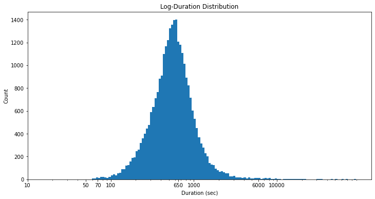

```python
# there's a long tail in the distribution, so let's put it on a log scale instead
log_binsize = 0.025
bins = 10 ** np.arange(1.2, np.log10(df_fgb['duration_sec'].max())+log_binsize, log_binsize)

plt.figure(figsize=[12, 6])
plt.hist(data = df_top10, x = 'duration_sec', bins = bins)
plt.xscale('log')
plt.xticks([10,50,70,100,650,1000,6000,10000], [10,50,70,100,650,1000,6000,10000])
plt.xlabel('Duration (sec)')
plt.ylabel('Count')
plt.title('Log-Duration Distribution');
```

From the figure, most durations of trips fall into 650 seconds (10.8 minutes). It looks normally distributed.

```python
# Only use the subsetted dataset to perform the rest of analysis.
df_top10.to_csv("201902-fordgobike-tripdata-clean.csv", index=False)
```